# Images_v2

*Machine learning No supervisado*  
*Semana 5:* *Generación de paleta de colores a partir de imágenes con técnicas de machine learning no supervisado*  
**Profesor:** *Haydemar Nuñez*  
**Fecha:** *25-02-2024*  
**Autores Notebook:** Estudiantes de la Maestría en Inteligencia Artificial

- *Jose Andres Carvajal Bautista - ja.carvajal2@uniandes.edu.co*
- *Alejandra Ossa Yepes - a.ossay@uniandes.edu.co*

## 1. Importación de librerías requeridas

```python
from Functions.Read_Images import Image
from Functions.Select_K_groups import ClusterNumber
from Functions.Segmentation import SegmentationProcess
from Functions.PlotResults import Plot_Segmentation, PlotDimentionalReductionMethods, PlotPalet, PlotDimentionalReductionSelector
from Functions.Manifold_Learning import DimentionalRedcution
import numpy as np
import glob
import time
import matplotlib.pyplot as plt
from collections import Counter
```

## 2.Metodologia

### 2.1 Preparacion y procesamiento de la imagen

Se lleva a cabo un procesamiento inicial de la imagen utilizando cv2.cvtColor() para convertirla al formato RGB. Posteriormente, se emplea la función cv2.resize() para ajustar el tamaño de la imagen a los parámetros especificados (new_width, new_length). Para este propósito, se utiliza el método de interpolación cv2.INTER_AREA, el cual se destaca por su capacidad para conservar la calidad y los detalles de la imagen al reducir significativamente sus dimensiones.

En este caso, la imagen original, con un tamaño promedio de 1000 x 1000 píxeles, se redimensiona a imágenes de tamaño 500 x 500 píxeles. Es importante mencionar que el método cv2.INTER_AREA se basa en el área de los píxeles, lo que contribuye a mantener la calidad visual de la imagen durante el proceso de redimensionamiento.

Además, se aplica la función cv2.GaussianBlur(), la cual devuelve una versión desenfocada y suavizada de la imagen. Este paso es fundamental para reducir el ruido y las irregularidades presentes en la imagen original. Es importante destacar que el parámetro smooth_kernel solo puede contener valores impares, ya que corresponde al tamaño del kernel del filtro Gaussiano utilizado en la operación.

Todo este proceso se integra en un pipeline, el cual se encarga de aplicar estas transformaciones a todas las imágenes antes de iniciar el proceso de segmentación. Para facilitar esta tarea, se utiliza la clase Image junto con el método Pipeline.

### 2.2 Selección de Número Clusters (K)

El objetivo de este proceso es determinar el número óptimo de clusters presentes en cada imagen, teniendo en cuenta la distribución de píxeles en la misma. Por lo tanto, se ejecuta este proceso para cada imagen, lo que resulta en un valor diferente de clusters para cada una. Este parámetro se varía en el rango de números enteros [5 - 11]. . Este intervalo se seleccionó de acuerdo con los requerimientos del proyecto.

Para lograr esto, se implementa el método MeanShift, el cual ayuda a determinar automáticamente el número de clusters basándose en la densidad de los datos en el espacio de características. Se realiza una variación en el ancho de banda utilizando la función estimate_bandwidth, ajustando el parámetro quantile en el intervalo (0.1, 0.6) de manera uniforme. Además del método MeanShift, se utiliza el algoritmo K-means, evaluando diferentes números de clusters en el rango [5 - 11]

Finalmente, los resultados obtenidos de estos algoritmos se comparan utilizando las métricas de Davies Bouldin, que es una medida de la "separabilidad" promedio entre los clusters, y Calinski Harabasz, que es una medida de la "cohesión" intra-cluster. Se seleccionan los tres mejores números de clusters utilizando la métrica Calinski Harabasz, y luego se filtra el mejor resultado utilizando la métrica Davies Bouldin.

### 2.3 Segmentación

En esta sección, se ajusta la clusterización de la imagen de acuerdo al número óptimo de clusters encontrado en la sección anterior. Para ello, se emplea el modelo Bisecting KMeans, el cual divide recursivamente los clusters en dos grupos hasta alcanzar el número deseado de clusters proporcionado por Davies Bouldin. Además, se utiliza el modelo Fuzzy C-Means para realizar un clustering difuso en el conjunto de datos, comenzando con una matriz de pesos aleatoria. Este enfoque se elige con el fin de observar la evolución del algoritmo según la naturaleza de los píxeles. Adicionalmente, se realizan variaciones en el parámetro de difusión m, que se encuentra en el rango [1.1, 1.5, 2.5].

Una vez completado el proceso de clustering, se realiza una comparación utilizando la métrica de Davies Bouldin, seleccionando el algoritmo con el menor valor de esta métrica. Posteriormente, se extraen los centroides de cada cluster, los cuales representan los valores correspondientes a la paleta de colores. Además, se muestra la distribución de cada color en la imagen para visualizar cómo están distribuidos en la misma.

### 2.4 Reducción de dimensionalidad

Se utiliza T-SNE para la reducción de dimensionalidad no lineal y la creación de un conjunto de muestras representativas de las imágenes. Además, se emplea PCA para la visualización de los dos primeros componentes principales, los cuales retienen la mayor parte de la varianza explicada en los datos. Adicionalmente se realiza un analisis de los canales en donde se escogen las caracteristicas por selección

En resumen, T-SNE se utiliza para crear una representación visual de las muestras en un espacio de dos dimensiones que conserva las relaciones no lineales entre los datos, mientras que PCA se emplea para resumir la información en los dos componentes principales que retienen la mayor parte de la variabilidad de los datos. Las imágenes finales proporcionan una comparación visual de cómo se comportan los datos en diferentes dimensiones y mediante diferentes métodos de reducción de dimensionalidad (lineales, no lineales y por selección).

## 3. Implementación

### 3.1 Parámetros

```python
new_width = 500
new_lenght = 500
smooth_kernel = (5,5)
total_datos = new_width*new_lenght
```

### 3.2 Resultados #1

#### 3.2.1 Imagen #1

Se procesa la imagen a través del Pipeline y se encuentra el valor óptimo de K.

```python
file  = 'Images/cubismo_1.jpeg'
image =  Image(file, new_width, new_lenght, smooth_kernel)
image.Pipeline()
image_processed = image.Preprocessed_image
best_algorithm, K  = ClusterNumber(image_processed, 3).Run()
print(f'El mejor valor de K (número de cluster) es: {K} y fue encontrado con el algortimo de {best_algorithm}')
```

```
El mejor valor de K (número de cluster) es: 10 y fue encontrado con el algortimo de Kmeans
```

Ahora se utiliza el valor optimo de K y los método de cluster para segmentar la imagen, se muestra la imagen orginal, segmentada y la distribución de colores

[figure not shown]

```python
centroids,  img_segmented, labels, davies_bouldin, model = SegmentationProcess(K, image_processed).Run()
Plot_Segmentation(image_processed, img_segmented, model, labels, centroids)
```

Se procede a realizar la reducción de dimensión utilizando t-SNE y PCA.

```python
data_embedded, transform_Data, data_pca  = DimentionalRedcution(image_processed, centroids, labels).Dimentional_reduction_Algorithms()
```

Se procede a mostrar los resultados utilizando selección de características, donde se seleccionan 2 canales de la imagen y se muestran los los resultados al variarlos.

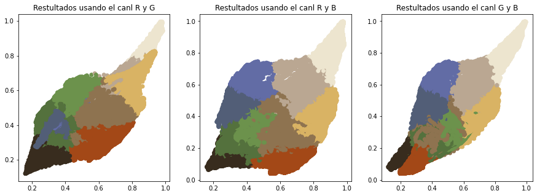

```python
PlotDimentionalReductionSelector(transform_Data,  centroids, labels)
```

Ahora se muestran los resultados obtenidos con PCA y t-SNE.

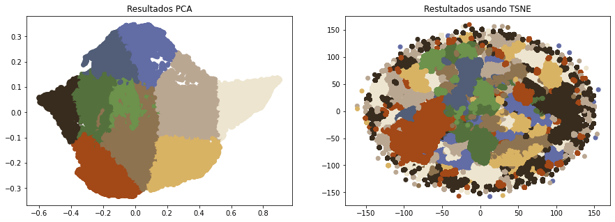

```python
PlotDimentionalReductionMethods(data_embedded, data_pca, centroids, labels)
```

Finalmente, se muestra la paleta de colores.

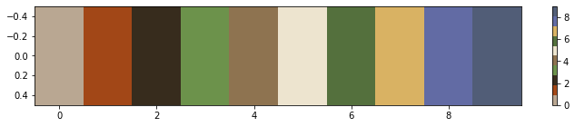

```python
PlotPalet(centroids)
```

#### Análisis de resultados Imagen #1

La Imagen #1 presenta un estilo de arte cubista, donde la forma original se caracteriza por colores y formas marcadas. La segmentación de la imagen en 10 colores, utilizando el modelo Fuzzy con un parámetro $m = 1.5$, logra una recreación efectiva de la imagen. En la gráfica de distribución de colores, se destaca que el color 4 (café oscuro) es el más prominente, representando un $13.84%$, mientras que el verde claro tiene la menor representación, con un $6.23%$.

Para la visualización de la imagen, se aplicaron técnicas de reducción de dimensionalidad como PCA y t-SNE. La representación resultante muestra que PCA exhibe clusters más compactos en comparación con t-SNE, que presenta una dispersión mayor. Sin embargo, ambas técnicas proporcionan una paleta de colores efectiva para recrear la imagen.

#### 3.2.2 Imagen #2

Se procesa la imagen a través del Pipeline y se encuentra el valor óptimo de K.

```python
file  = 'Images/Fauvis.jpeg'
image =  Image(file, new_width, new_lenght, smooth_kernel)
image.Pipeline()
image_processed = image.Preprocessed_image
best_algorithm, K  = ClusterNumber(image_processed, 3).Run()
print(f'El mejor valor de K (número de cluster) es: {K} y fue encontrado con el algortimo de {best_algorithm}')
```

```
El mejor valor de K (número de cluster) es: 6 y fue encontrado con el algortimo de Kmeans
```

Ahora se utiliza el valor optimo de K y los método de cluster para segmentar la imagen, se muestra la imagen orginal, segmentada y la distribución de colores

[figure not shown]

```python
centroids,  img_segmented, labels, davies_bouldin, model = SegmentationProcess(K, image_processed).Run()
Plot_Segmentation(image_processed, img_segmented, model, labels, centroids)
```

Se procede a realizar la reducción de dimensión utilizando t-SNE y PCA.

```python
data_embedded, transform_Data, data_pca  = DimentionalRedcution(image_processed, centroids, labels).Dimentional_reduction_Algorithms()
```

Se procede a mostrar los resultados utilizando selección de características, donde se seleccionan 2 canales de la imagen y se muestran los los resultados al variarlos.

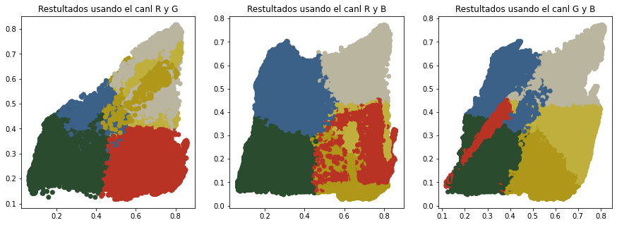

```python
PlotDimentionalReductionSelector(transform_Data,  centroids, labels)
```

Ahora se muestran los resultados obtenidos con PCA y t-SNE.

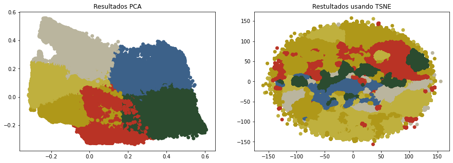

```python
PlotDimentionalReductionMethods(data_embedded, data_pca, centroids, labels)
```

Finalmente, se muestra la paleta de colores.

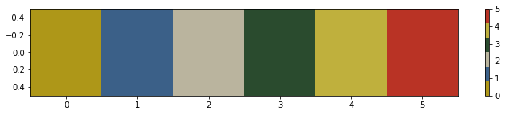

```python
PlotPalet(centroids)
```

#### Análisis de resultados Imagen #2

Para la reducción de dimensionalidad, se graficaron las tres combinaciones de los dos canales $(RG, RB, GB)$ con fines comparativos. Se utilizaron técnicas de PCA y t-SNE para visualizar la imagen. La representación resultante muestra que PCA exhibe clusters más compactos en comparación con t-SNE, que presenta una dispersión mayor. Sin embargo, ambas técnicas proporcionan una paleta de 6 colores efectiva para recrear la imagen.

#### 3.2.3 Imagen #3

Se procesa la imagen a través del Pipeline y se encuentra el valor óptimo de K.

```python
file  = 'Images/Naives.jpeg'
image =  Image(file, new_width, new_lenght, smooth_kernel)
image.Pipeline()
image_processed = image.Preprocessed_image
best_algorithm, K  = ClusterNumber(image_processed, 3).Run()
print(f'El mejor valor de K (número de cluster) es: {K} y fue encontrado con el algortimo de {best_algorithm}')
```

```
El mejor valor de K (número de cluster) es: 10 y fue encontrado con el algortimo de Kmeans
```

Ahora se utiliza el valor optimo de K y los método de cluster para segmentar la imagen, se muestra la imagen orginal, segmentada y la distribución de colores

[figure not shown]

```python
centroids,  img_segmented, labels, davies_bouldin, model = SegmentationProcess(K, image_processed).Run()
Plot_Segmentation(image_processed, img_segmented, model, labels, centroids)
```

Se procede a realizar la reducción de dimensión utilizando t-SNE y PCA.

```python
data_embedded, transform_Data, data_pca  = DimentionalRedcution(image_processed, centroids, labels).Dimentional_reduction_Algorithms()
```

Se procede a mostrar los resultados utilizando selección de características, donde se seleccionan 2 canales de la imagen y se muestran los los resultados al variarlos.

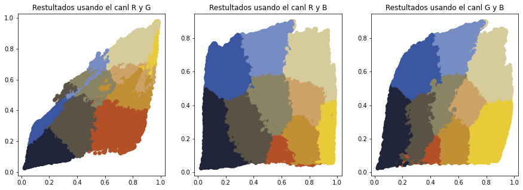

```python
PlotDimentionalReductionSelector(transform_Data,  centroids, labels)
```

Ahora se muestran los resultados obtenidos con PCA y t-SNE.

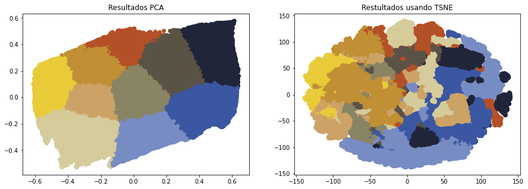

```python
PlotDimentionalReductionMethods(data_embedded, data_pca, centroids, labels)
```

Finalmente, se muestra la paleta de colores.

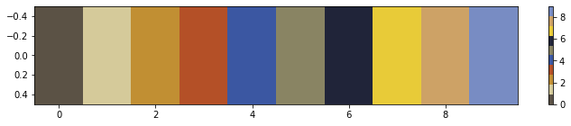

```python
PlotPalet(centroids)
```

#### Análisis de resultados Imagen #3

Para la reducción de dimensionalidad, se graficaron las tres combinaciones de los dos canales $(RG, RB, GB)$ con fines comparativos. Se emplearon técnicas de PCA y t-SNE para visualizar la imagen. La representación resultante muestra que PCA exhibe clusters más compactos en comparación con t-SNE, que presenta una mayor dispersión. Sin embargo, ambas técnicas proporcionan una paleta de 10 colores efectiva para recrear la imagen.

#### 3.2.4 Imagen #4

Se procesa la imagen a través del Pipeline y se encuentra el valor óptimo de K.

```python
file  = 'Images/Pollis.jpeg'
image =  Image(file, new_width, new_lenght, smooth_kernel)
image.Pipeline()
image_processed = image.Preprocessed_image
best_algorithm, K  = ClusterNumber(image_processed, 3).Run()
print(f'El mejor valor de K (número de cluster) es: {K} y fue encontrado con el algortimo de {best_algorithm}')
```

```
El mejor valor de K (número de cluster) es: 8 y fue encontrado con el algortimo de MeanShift
```

Ahora se utiliza el valor optimo de K y los método de cluster para segmentar la imagen, se muestra la imagen orginal, segmentada y la distribución de colores

[figure not shown]

```python
centroids,  img_segmented, labels, davies_bouldin, model = SegmentationProcess(K, image_processed).Run()
Plot_Segmentation(image_processed, img_segmented, model, labels, centroids)
```

Se procede a realizar la reducción de dimensión utilizando t-SNE y PCA.

```python
data_embedded, transform_Data, data_pca  = DimentionalRedcution(image_processed, centroids, labels).Dimentional_reduction_Algorithms()
```

Se procede a mostrar los resultados utilizando selección de características, donde se seleccionan 2 canales de la imagen y se muestran los los resultados al variarlos.

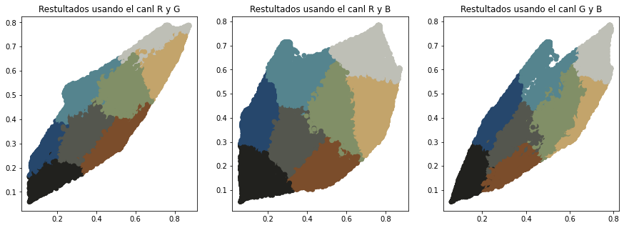

```python
PlotDimentionalReductionSelector(transform_Data,  centroids, labels)
```

Ahora se muestran los resultados obtenidos con PCA y t-SNE.

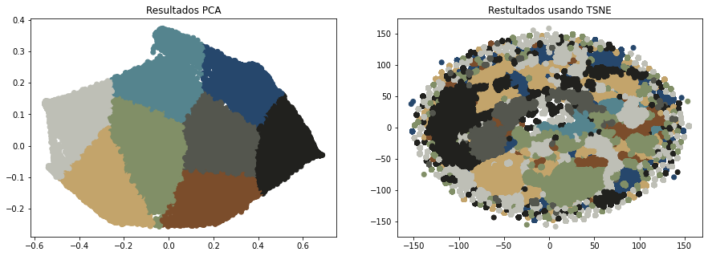

```python
PlotDimentionalReductionMethods(data_embedded, data_pca, centroids, labels)
```

Finalmente, se muestra la paleta de colores.

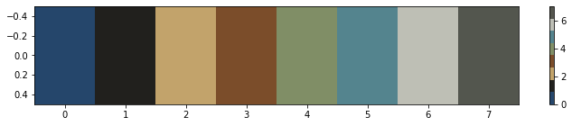

```python
PlotPalet(centroids)
```

#### Análisis de resultados Imagen #4

Para la reducción de dimensionalidad, se graficaron las tres combinaciones de los dos canales $(RG, RB, GB)$ con fines comparativos. Se utilizaron técnicas de PCA y t-SNE para la visualización de la imagen. La representación resultante muestra que PCA exhibe clusters más compactos en comparación con t-SNE, que presenta una mayor dispersión. Sin embargo, ambas técnicas proporcionan una paleta de 8 colores efectiva para recrear la imagen.

## 4. Conclusiones

Por otro lado, al aplicar técnicas de reducción de dimensionalidad, se observa que con t-SNE se genera un espacio circular de los datos donde la agrupación de píxeles no es muy clara, ya que se mezclan entre sí. En cambio, con PCA y utilizando selección de características, la representación permite visualizar las regiones de decisión de pertenencia de cada cluster. Es importante señalar que los centroides de cada cluster no representan exactamente un elemento de este, sino que se calculan utilizando el promedio de los datos. Aun así, se obtiene una representación aproximada del color perteneciente a la imagen. Para obtener una aproximación más precisa de la paleta de colores, se podría utilizar el método de k-medoides, que permite seleccionar el centroide como un dato explícito del cluster, aunque con un costo computacional mucho mayor.

En conclusión, la capacidad de generar la paleta de colores de una imagen es una tarea de gran interés, ya que a través de estos algoritmos de aprendizaje no supervisado se puede capturar la información explícita de los colores relevantes, lo cual no es una tarea sencilla a nivel de la visión humana.

## Cierre

En este notebook se implementara un desarrollo que use técnicas de preparación, agrupación y segmentación de 4 imagenes, que permita extraer los tonos de una imagen y generar un muestrario de los colores presentes en esta.

*Versión de: Febrero 24, 2024*  
*Universidad de los Andes*